# Weibull Analysis with {weibulltools}

Tim-Gunnar Hensel

David Barkemeyer

16 2 2021

For performing an introductory Weibull analysis, we will use the `shock` dataset, which is included in {weibulltools}.

```r
library(weibulltools)
shock
```

```
#> # A tibble: 38 x 3
#>    distance failure_mode status
#>       <int> <chr>         <dbl>
#>  1     6700 mode_1            1
#>  2     6950 censored          0
#>  3     7820 censored          0
#>  4     8790 censored          0
#>  5     9120 mode_2            1
#>  6     9660 censored          0
#>  7     9820 censored          0
#>  8    11310 censored          0
#>  9    11690 censored          0
#> 10    11850 censored          0
#> # ... with 28 more rows
```

In this dataset kilometer-dependent problems that have occurred on shock absorbers are reported. In addition to failed items the dataset also contains *censored* observations. The data can be found in *Statistical Methods for Reliability Data* [^1].

For consistent handling of the data, {weibulltools} introduces the function `reliability_data()` that converts the original dataset into a formatted object which allows to easily apply the presented methods.

```r
shock_tbl <- reliability_data(data = shock, x = distance, status = status)
shock_tbl
```

```
#> Reliability Data with characteristic x: 'distance':
#> # A tibble: 38 x 3
#>        x status id
#>    <int>  <dbl> <chr>
#>  1  6700      1 ID1
#>  2  6950      0 ID2
#>  3  7820      0 ID3
#>  4  8790      0 ID4
#>  5  9120      1 ID5
#>  6  9660      0 ID6
#>  7  9820      0 ID7
#>  8 11310      0 ID8
#>  9 11690      0 ID9
#> 10 11850      0 ID10
#> # ... with 28 more rows
```

## Estimation of Failure Probabilities

First, we are interested in how censored observations influence the estimation of failure probabilities in comparison to the case where only failed units are considered. To deal with survived and failed units we will use `estimate_cdf()` with `methods = "johnson"`, whereas `methods = "mr"` only considers failures.

```r
# Estimate CDF with both methods:
shock_cdf <- estimate_cdf(shock_tbl, methods = c("mr", "johnson"))
```

```
#> The 'mr' method only considers failed units (status == 1) and does not retain intact units (status == 0).
```

```r
# First case where only failed units are taken into account:
shock_cdf_mr <- shock_cdf %>% filter(cdf_estimation_method == "mr")
shock_cdf_mr
```

```
#> CDF estimation for method 'mr':
#> # A tibble: 11 x 6
#>    id        x status  rank   prob cdf_estimation_method
#>    <chr> <int>  <dbl> <dbl>  <dbl> <chr>
#>  1 ID1    6700      1     1 0.0614 mr
#>  2 ID5    9120      1     2 0.149  mr
#>  3 ID13  12200      1     3 0.237  mr
#>  4 ID15  13150      1     4 0.325  mr
#>  5 ID19  14300      1     5 0.412  mr
#>  6 ID20  17520      1     6 0.5    mr
#>  7 ID27  20100      1     7 0.588  mr
#>  8 ID31  20900      1     8 0.675  mr
#>  9 ID32  22700      1     9 0.763  mr
#> 10 ID34  26510      1    10 0.851  mr
#> 11 ID36  27490      1    11 0.939  mr
```

```r
# Second case where both, survived and failed units are considered:
shock_cdf_john <- shock_cdf %>% filter(cdf_estimation_method == "johnson")
shock_cdf_john
```

```
#> CDF estimation for method 'johnson':
#> # A tibble: 38 x 6
#>    id        x status  rank    prob cdf_estimation_method
#>    <chr> <int>  <dbl> <dbl>   <dbl> <chr>
#>  1 ID1    6700      1  1     0.0182 johnson
#>  2 ID2    6950      0 NA    NA      johnson
#>  3 ID3    7820      0 NA    NA      johnson
#>  4 ID4    8790      0 NA    NA      johnson
#>  5 ID5    9120      1  2.09  0.0465 johnson
#>  6 ID6    9660      0 NA    NA      johnson
#>  7 ID7    9820      0 NA    NA      johnson
#>  8 ID8   11310      0 NA    NA      johnson
#>  9 ID9   11690      0 NA    NA      johnson
#> 10 ID10  11850      0 NA    NA      johnson
#> # ... with 28 more rows
```

If we compare both outputs we can see that survivors reduce the probabilities since undamaged units with longer or equal lifetime characteristic *x* let us gain confidence in the product.

## Probability Plotting

The estimated probabilities can now be presented in a probability plot. With `plot_prob()` probability plots for several lifetime distributions can be constructed and estimates of multiple methods can be displayed at once. The axes are transformed in such a way that the *cumulative distribution function (CDF)* is represented through a straight line. If the plotted probabilities lie on an approximately straight line it can be said that the chosen distribution is adequate.

### Weibull Probability Plot

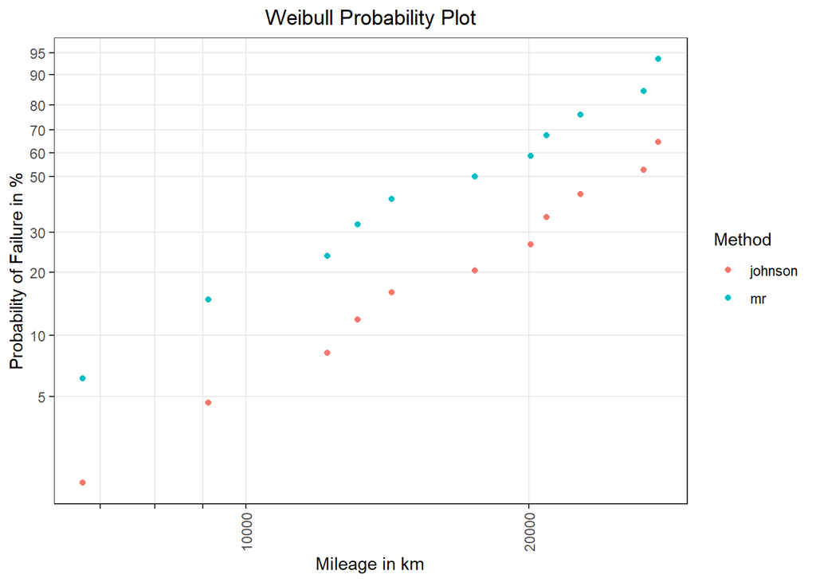

Figure 3: Plotting positions in Weibull grid.

```r
# Weibull grid for estimated probabilities:
weibull_grid <- plot_prob(
  shock_cdf,
  distribution = "weibull",
  title_main = "Weibull Probability Plot",
  title_x = "Mileage in km",
  title_y = "Probability of Failure in %",
  title_trace = "Method",
  plot_method = "ggplot2"
)

weibull_grid
```

*Figure 3* shows that the consideration of survivors (orange points, *Method: johnson*) decreases the failure probability in comparison to the sole evaluation of failed items (green points, *Method: mr*).

### Log-normal Probability Plot

Finally, we want to use a log-normal probability plot to visualize the estimated failure probabilities.

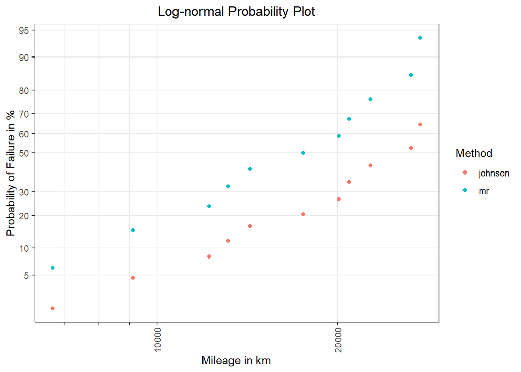

Figure 4: Plotting positions in log-normal grid.

```r
# Log-normal grid for estimated probabilities:
lognorm_grid <- plot_prob(
  shock_cdf,
  distribution = "lognormal",
  title_main = "Log-normal Probability Plot",
  title_x = "Mileage in km",
  title_y = "Probability of Failure in %",
  title_trace = "Method",
  plot_method = "ggplot2"
)

lognorm_grid
```

On the basis of *Figure 3* and *Figure 4* we can subjectively assess the goodness of fit of Weibull and log-normal. It can be seen that in both grids, the plotted points roughly fall on a straight line. Hence one can say that the Weibull as well as the log-normal are good model candidates for the `shock` data.

## Estimation of parametric lifetime distributions

{weibulltools} comes with two basic methods for the parameter estimation of lifetime distributions. Whereas `rank_regression()` fits a straight line through the plotting positions of the just calculated failure probabilites, `ml_estimation()` strives to maximize a function of the parameters given the sample data. After the parameters are obtained, a cumulative distribution function *(CDF)* can be computed and added to a probability plot with `plot_mod()`. `rank_regression()` and `ml_estimation()` can be applied to complete data as well as failure and (multiple) right-censored data. Both methods can also deal with three-parametric models that include a threshold parameter $\gamma$.

### RR for two-parameter Weibull distribution

```r
# Estimating two-parameter Weibull:
rr_weibull <- rank_regression(shock_cdf, distribution = "weibull")
rr_weibull
```

```
#> List of 2 model estimations:
#> Rank Regression
#> Coefficients:
#>      mu    sigma
#> 10.2596   0.3632
#> Method of CDF Estimation: johnson
#>
#> Rank Regression
#> Coefficients:
#>     mu   sigma
#> 9.8859  0.3956
#> Method of CDF Estimation: mr
```

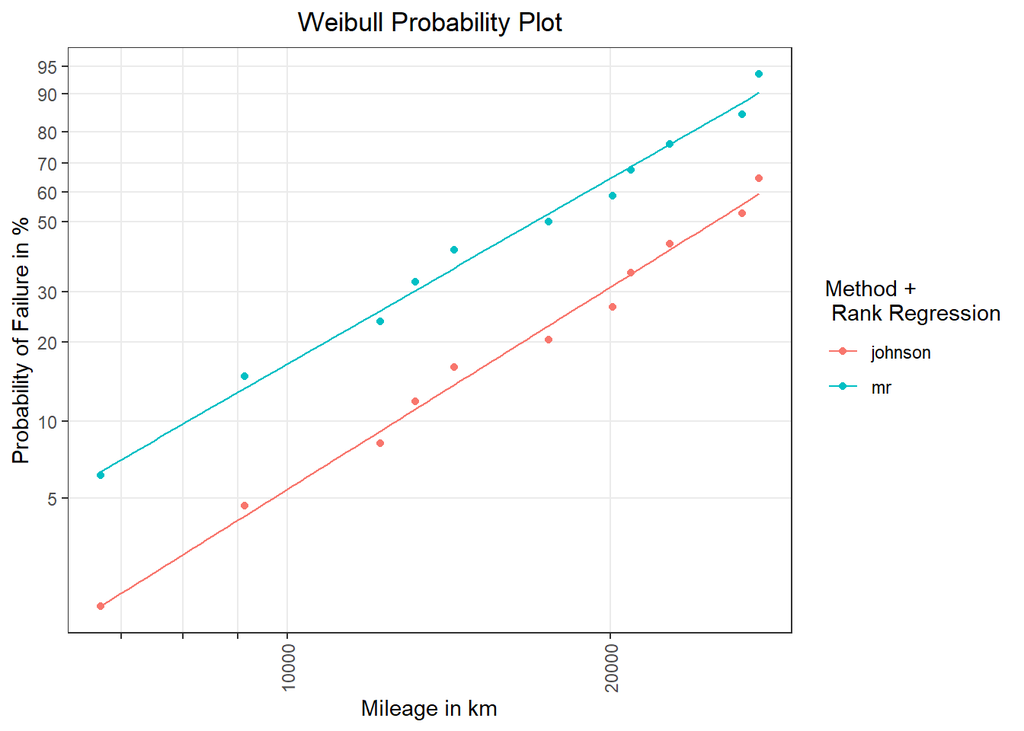

Figure 1: RR for a two-parametric Weibull distribution.

```r
# Add regression line to probability plot:
weibull_plot_rr <- plot_mod(
  weibull_grid,
  x = rr_weibull,
  title_trace = "Rank Regression"
)

weibull_plot_rr
```

### ML for two-parameter Weibull distribution

```r
# Again estimating Weibull:
ml_weibull <- ml_estimation(
  shock_tbl,
  distribution = "weibull"
)

ml_weibull
```

```
#> Maximum Likelihood Estimation
#> Coefficients:
#>      mu    sigma
#> 10.2299   0.3164
```

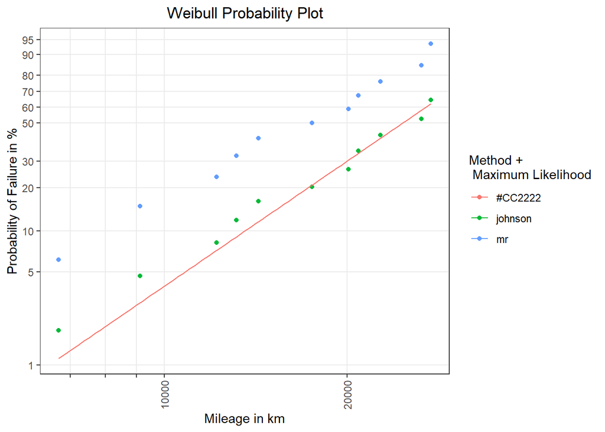

Figure 2: ML for a two-parametric Weibull distribution.

```r
# Add ML estimation to weibull_grid:
weibull_plot_ml <- plot_mod(
  weibull_grid,
  x = ml_weibull,
  title_trace = "Maximum Likelihood"
)

weibull_plot_ml
```

[^1]: Meeker, W. Q.; Escobar, L. A.: *Statistical Methods for Reliability Data*, *New York, Wiley series in probability and statistics*, 1998, p. 630